# EFI Deep Dive

### Work on the legend intervals

Change the spacing of the interval. The intervals can be keyed in directly using and style to change the type of breaks

1. “fixed”: User-defined fixed breaks.

2. “pretty”: Breaks at pretty intervals (often used for visual appeal).

3. “quantile”: Breaks at quantile intervals (each class has an equal number of observations).

4. “equal”: Breaks at equal intervals.

5. “kmeans”: Breaks determined by k-means clustering.

6. “hclust”: Breaks determined by hierarchical clustering.

7. “bclust”: Breaks determined by bin-based clustering.

8. “fisher”: Breaks determined by Fisher-Jenks natural breaks optimization.

9. “jenks”: Another name for Fisher-Jenks breaks.

10. “sd”: Breaks determined by standard deviations from the mean.

11. “log10_pretty”: Breaks determined by log10 transformed values with pretty intervals.

12. “cont”: Continuous color scale (no discrete breaks).

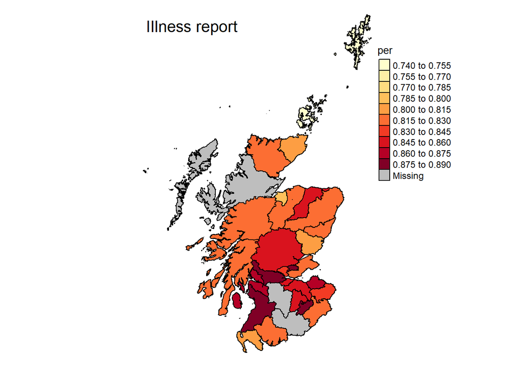

```r
tm_shape(MergedGeo) + # Specify the spatial object (MergedGeo) to be used in the map
  tm_fill("per", style = "equal", n = 10, palette = color.palette, colorNA = "grey") + # Fill polygons based on 'per' variable; use equal interval classification with 10 classes; custom color palette; grey for NA values
  tm_borders(col = "black") + # Add black borders to each polygon
  tm_layout(title = "Illness report", legend.text.size = 0.75, legend.title.size = 1, frame = FALSE, legend.position = c(1, 0.5)) # Set layout: add a title, resize legend text and title, remove frame, position legend at (1, 0.5)
```

## Now we can work on a different subject: Witches

The steps are always the same first we need to search keywords and then we merge the results with our map of Scotland.

### Preparing the data set

```r
Parish$witches<- ifelse(grepl("witch|spell|witches|enchantemt|magic", Parish$text, ignore.case = T), "yes","no")
```

Can you think to other keywords? just add them to the code above.

Then we group by

```r
WitchGroup <- Parish %>%
  group_by(Area) %>%
  summarise(Total = n(), count = sum(witches == "yes")) %>%
  mutate(per = round(count / Total, 2))
```

And finally we merge

```r
MergedGeo2 <-merge(ParishesGeo,WitchGroup, by.x="JOIN_NAME_", by.y="Area", all.x = TRUE) # nb this is left join cause I want to preserve all the records present in ParishGeo
```

Let’s create a more “witchy” Palette

```r
color.palette2 <- colorRampPalette(c("white", "purple"), alpha = 0.5)
```

### Plot the result

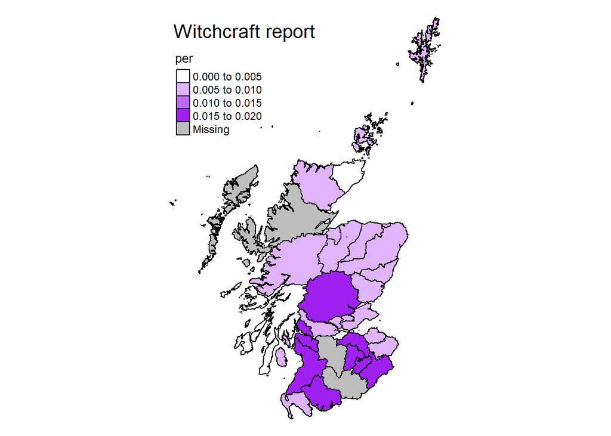

```r
tm_shape(MergedGeo2) +
  tm_fill("per", palette = color.palette2(100), colorNA = "grey") +
  tm_borders(col = "black")+
  tm_layout(title = "Witchcraft report",
            legend.text.size = 0.75,
            legend.title.size = 1,
            frame = FALSE)
```

### Refine the results:Adding scale bar and north arrow

Adding the scale bar and north arrow to the map using tmap is a lot simpler.

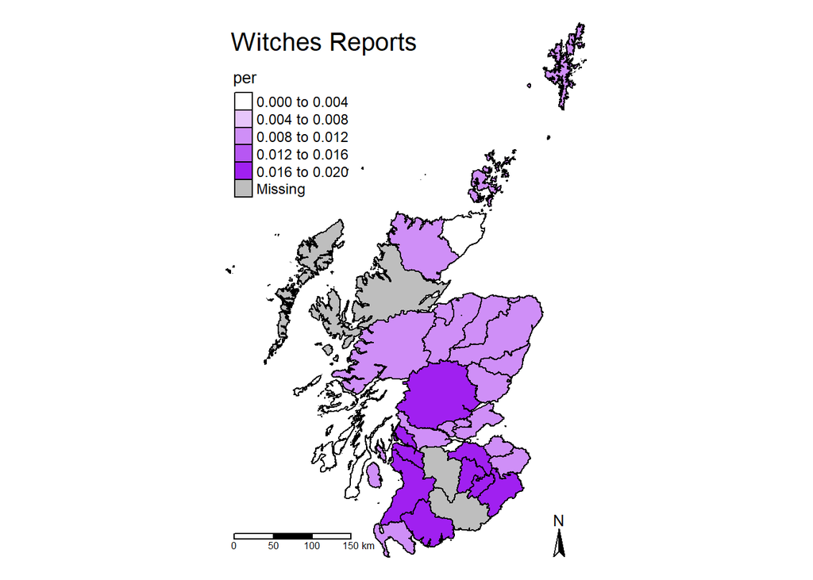

```r
tm_shape(MergedGeo2) +
  tm_fill("per",
          style = "equal",
          n = 5,
          palette = color.palette2(100),
          colorNA = "grey") +
  tm_borders(col = "black")+
  tm_layout(title = "Witches Reports",
            legend.text.size = 0.75,
            legend.title.size = 1,
            frame = FALSE) +
  tm_scale_bar(position = "left") + #add scalebar
  tm_compass(size = 1.5)#add north arrow
```